# Linear models

Machine learning is about learning patterns from data. *Deep learning* is a subset of machine learning, where we'll build neural networks to identify patterns. We'll first need a strong understanding of *linear models*.

### What's a linear model?

> A *linear model* is simply an equation where each term is either:
> - a constant, or
> - a product of a parameter and a variable

> For example, $ax + b = 0$ and $ax^2 + bx + c = 0$ are both linear models where $x$ is a variable and $a, b, c$ are constant terms.

> Despite the $x^2$ term, $ax^2+bx+c = 0$ is a linear model because the model is linear in the *parameter* $x^2$: we multiply it by some constant $a$. If this is confusing, imagine setting $x' = x^2$ and substituting it into the model: then our model is $ax' + bx +c = 0$, which is easier to identify as linear.

We'll find out soon that the core of all neural networks is a set of nonlinear functions. This nonlinearity makes neural networks - as you might have heard - very powerful. Soon we'll build those nonlinear functions ourselves.

First, we need to build a few linear functions. Then we can transform them into a powerful nonlinear form.

## Lines in higher dimensions

Most students will be familiar with the equation of a line. For example, $y = -2x$ is an equation for a line. Rewriting this equation lets us generalize the line equation to higher dimensions. First, convert into the normal form, $2x + y = 0$. Then, we can represent the normal form as the dot product $\big\langle (2,1), (x,y) \big\rangle = 0$. Finally, we can represent all lines passing through any point by adding a *bias* weight. The *bias* is a constant; for example, the line equations $$ \big\langle (2,1), (x,y) \big\rangle -1 = 0 \\ 2x + y = 1 \\ y = -2x + 1 $$ are equivalent. Finally, we can generalize this linear model to the form most popular in machine learning: $$ w^Tx + b = 0 $$ which expands to the equation of a *hyperplane*: $w_1x_1 + w_2x_2 + \dots + w_nx_n + b = 0$. That looks uncoincidentally like our original line equation, but now in $n$ dimensions: in fact, a point is a *hyperplane* in $1$-dimensional space, a line is a *hyperplane* in $2$-dimensional space, and a plane is a *hyperplane* in $3$-dimensional space.

### The hyperplane

> *Hyperplane*: A subspace that separates a vector space into two parts. A linear equation for a *hyperplane* lets us perform classification (for two classes) easily: an input we want to classify as class $0$ or class $1$ is either above or below the *hyperplane*.

> Formally, a *hyperplane* is a subspace of dimension $n-1$ inside an $n$-dimensional space.

[figure not shown]

> > **Left:** a line is a hyperplane in $2$-D space. **Right**: a plane is a hyperplane in $3$-D space.

### Classification using hyperplanes

A *decision function* performs classification: given a point, it classifies that point as belonging to a certain set.

Let's define a function $f:\mathbb{R}^n\rightarrow \mathbb{R}$. If you're not familiar with this notation, it just means that $f$ takes an $n$-dimensional input, and outputs a real number. We'll define $f$ using our hyperplane equation. $$ f(x) = w^T x + b $$ Then two points --- let's call them $x_1, x_2$ --- located on opposite sides of that hyperplane will together satisfy one of the following inequalities: $$ f(x_1) < 0 < f(x_2) \\ f(x_2) < 0 < f(x_1) $$

So our *decision function* could be as concise as $sign\big(f(x)\big)$, since that function outputs whether $f(x) > 0$ or $f(x) < 0$.

## Perceptron algorithm

The **perceptron** is a learning algorithm. It finds a separating *hyperplane* by minimizing the distance of misclassified points to the *decision boundary*.

### Training

All machine learning models need to be trained (fitted) to adjust their parameters and learn from a dataset. The perceptron is no exception. A perceptron finds its separating hyperplane $f(x) = w^T x + b$ by repeating two steps:

1. Check if the separating hyperplane misclassified (made a mistake on) any point.
2. If so, *update* the coefficient vector ($w$) and bias ($b$) to remove that mistake.

The algorithm stops once all points are correctly classified. We can *update* $w$ and $b$ to fix a mistaken classification using the following rule:

#### Perceptron update rule

Let $x= $ an input point (e.g. a column vector), and $y \in \{0, 1\}= $ the ground truth label for that point. $f(x)$ satisfies one of three conditions:

1. If $f(x) = y$, then $f(x)$ made no mistake; no change.
2. If $f(x) = 1$ but $y=0$, then $w \leftarrow w-x$.
3. If $f(x) = 0$ but $y=1$, then $w \leftarrow w+x$.

We can condense this update rule further by observing that the expression $\big(y-f(x)\big)\in \{ -1, 1\}$ whenever $f(x)$ has made a mistake. Condensing (2.) and (3.):

1. If $f(x) = y$, no change
2. Else $w \leftarrow w + \big(y-f(x)\big)\cdot x$

This update rule pushes the hyperplane closer to any point misclassified by the perceptron. Perceptron convergence is guaranteed for any *linearly separable* dataset.

#### Simplifying out $b$

You'll notice we omitted any mention of the bias term $b$ in the update rule. For simplicity, linear models often append the bias term to the weight vector $w$. Appending $1$ to an input point $x$ lets us effectively compute the bias term using our dot product:

\begin{align*} w := \begin{bmatrix}w_0\\w_1\\ \vdots \\ w_n \end{bmatrix} \quad x := \begin{bmatrix} x_0\\x_1\\ \vdots \\ x_n\end{bmatrix} & \quad \quad \quad w' := \begin{bmatrix}w_0\\w_1\\ \vdots \\ w_n \\ b \end{bmatrix} \quad x' := \begin{bmatrix} x_0\\x_1\\ \vdots \\ x_n \\ 1\end{bmatrix} \\ \\ \langle w', x' \rangle &= w_0 x_0 + w_1 x_1 + \dots + w_n x_n + b(1) \\ &= \langle w, x \rangle + b \end{align*}

### Psuedocode

```
X, y = training_data, training_labels
w = [0, 0, ..., 0]
b = 0
while(any points misclassified):
    for each (x, y) in (X, Y):
         f = w^T * x
         w = w + (y-f)*x
```

This version of the perceptron algorithm is considered the *Rosenblatt perceptron*. Other variations of the perceptron allow you to set a *hyperparameter* $\eta$ (*eta*) which controls the rate of convergence of the separating hyperplane. Deep learning texts often refer to $\eta$ as the *learning rate*, since the $\eta$ term directly affects the rate at which an algorithm updates.

The learning rate $\eta$ does this by scaling the update rule: instead of setting $w \leftarrow w+\big(y - f(x)\big)\cdot x$, we set $w \leftarrow w + \eta\big(y-f(x)\big)\cdot x$. A larger $\eta$ (e.g. $\eta > 1 $) will tend to converge to a separating hyperplane faster, but also risks converging more slowly due to overshooting the decision boundary. A smaller $\eta$ (e.g. $\eta < 1$) will potentially find a more optimal separating hyperplane (i.e. one that maximizes distance to all points), but will also take longer to converge as we need to perform more updates.

We'll encounter this tradeoff between speed and cost again very soon, especially while learning about *gradient descent*.

### Hyperparameters

> Neural networks by definition 'learn' parameters (weights) from training data. We can configure how a neural network learns by setting *hyperparameters*, which are continuous/integer-valued values manually set prior to training a model. The perceptron learning rate term $\eta$ is a hyperparameter set by you prior to the learning process.

### Implementation

Here's a quick `numpy` implementation.

```python
import matplotlib.pyplot as plt
import numpy as np
```

```python
X = np.array([
    [0.8, 0.4],
    [0.3, 0.1],
    [0.8, 0.8],
    [0.4, 0.6],
    [0.6, 0.8],
    [0.4, 0.2],
    [0.4, 0.5],
])
Y = np.array([0, 0, 1, 1, 1, 0, 1])
```

```python
def plot_points(X, Y, ax, c_pos='b', c_neg='r'):
    for i, x in enumerate(X):
        ax.scatter(x[0], x[1], s=120,
                   marker=('_' if Y[i] <= 0 else '+'), linewidths=2,
                   c=(c_neg if Y[i] <= 0 else c_pos))
```

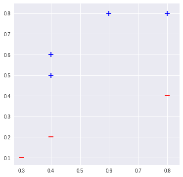

```python
fig, ax = plt.subplots(figsize=(6, 6))
plot_points(X, Y, ax)
```

```python
def train(X, Y):
    w = np.zeros(X.shape[1]+1)
    epochs = 100
    for e in range(epochs):
        for x, y in zip(X, Y):
            pred = np.where((np.dot(w[:2], x)+w[2]) >= 0.0, 1, 0)
            w[:2] += (y-pred) * x
            w[2] += (y-pred)
    return w

def predict(w, x):
    return np.where((np.dot(w[:2], x)+w[2]) > 0.0, 1, 0)
```

```python
w = train(X, Y)
```

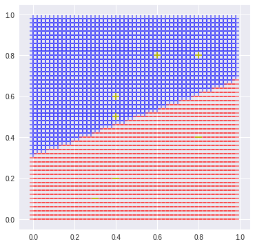

```python
fig, ax = plt.subplots(figsize=(6, 6))
for a in range(0, 50):
    for b in range(0, 50):
        i, j = a/50, b/50
        p = predict(w, [i, j])
        ax.scatter(i, j, s=120, marker=('_' if p <= 0 else '+'), linewidths=2,
                   c=('r' if p <= 0 else 'b'), alpha=0.5
                   )
plot_points(X, Y, ax, c_pos='y', c_neg='y')
```

But linear models have limitations. In the 1980s the perceptron algorithm represented the state-of-the-art in deep learning, but it can't learn the XOR function:

\begin{align*} f\big([0,1], w\big) &= 1 \\ f\big([1,0], w\big) &= 1 \\ f\big([1,1], w\big) &= 0 \\ f\big([0,0], w\big) &= 0 \end{align*}

Limitations like these resulted in the first AI winter.

# Activation functions

## Motivation

Deep learning is fundamentally a method of scalably building and training nonlinear models on large datasets. We've already achieved robust linear model performance for linearly separable datasets, using the Perceptron algorithm. To make these models useful in more complex datasets, we need to build in nonlinearity.

An *activation function* (represented commonly and here as $\phi$) takes the output value of a linear function such as $w^T x + b$ and returns a nonlinear transformation of that value. This behavior has biological origins:

### Biological neurons

Biological neurons receive signals via *dendrites* and output signals via an *axon*, which in turn passes signals across synapses to the *dendrites* of other neurons. Neurons *fire* by sending a voltage spike along the axon. The frequency of voltage spikes along the axon is a neuron's *firing rate*. The deep learning analogue of a neuron's *firing rate* is an *activation function*:

| Biological | Artificial |
| --- | --- |
| Neuron firing rate | Activation function $\phi$ |
| Voltage spike | $\phi(x)$ |
| Axon signal | $x$ |
| Synaptic strength | $w^T$ |

## Fundamental equations

In deep learning, an activation function $\phi : \mathbb{R} \rightarrow \mathbb{R} $ is usually set to one of the following.

### Logistic sigmoid

$$ \sigma(x) = \frac{1}{1+e^{-x}} $$ The *sigmoid* non-linearity takes an input $x \in \mathbb{R}$ and squashes it into an output $ 0 \leq \sigma(x) \leq 1$. The sigmoid *saturates* with a very positive or very negative $x$; at extreme values of $x$, it becomes flat and varies only very slightly in response to small changes of $x$.

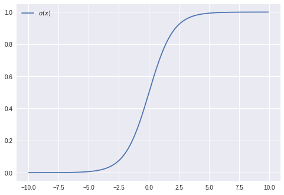

```python
import matplotlib.pyplot as plt
import numpy as np

X = np.arange(-10., 10., 0.1)
sigmoid = lambda x: 1/(1+np.exp(-x))
plt.plot(X, [sigmoid(x) for x in X], label='$\sigma(x)$')
plt.legend();
```

### Hyperbolic tangent

\begin{align*} tanh(x) &= \frac{e^x - e^{-x}}{e^x + e^{-x}} \end{align*} The *tanh* non-linearity also takes an input $x \in \mathbb{R}$ and squashes it into an output $ -1 \leq \sigma(x) \leq 1$. Like the logistic sigmoid, *tanh* saturates at extreme values of $x$. Unlike the logistic sigmoid, the *tanh* function is centered at $0$. This makes sense because the *tanh* function is actually just a scaled sigmoid: \begin{align*} tanh(x) &= \frac{e^x - e^{-x}}{e^x + e^{-x}} \\ &= \frac{1-e^{-2x}}{1+e^{-2x}} \\ &= \frac{2}{1+e^{-2x}}-1 \\ &= 2\sigma(2x)-1 \end{align*}

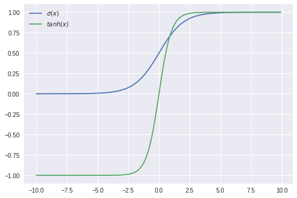

```python
import matplotlib.pyplot as plt
import numpy as np

X = np.arange(-10., 10., 0.1)
def tanh(x):
  u = np.exp(x)
  v = 1/u
  return (u-v)/(u+v)

plt.plot(X, [sigmoid(x) for x in X], label='$\sigma(x)$')
plt.plot(X, [tanh(x) for x in X], label='$tanh(x)$')
plt.legend();
```

### Rectified linear unit

$$ g(x) = max(0, x) $$

The rectified linear unit (*ReLU*) thresholds the activation at $0$. The *ReLU* function, consisting of no exponential operations, is easier and faster to compute than the logistic sigmoid or hyperbolic tangent activation functions. The *ReLU* also does not saturate at extreme values, instead simply behaving linearly.

[figure not shown]

```python
import matplotlib.pyplot as plt
import numpy as np

X = np.arange(-5., 5., 0.1)
relu = lambda x: max(0, x)

plt.plot(X, [sigmoid(x) for x in X], label='$\sigma(x)$')
plt.plot(X, [tanh(x) for x in X], label='$tanh(x)$')
plt.plot(X, [relu(x) for x in X], label='$ReLU(x)$')
plt.legend();
```

### Usage

In Linear models we discussed the behavior of a a linear model defined by a weight vector $w$, a bias term $b$, and an input vector $x$: $$ w^T x + b $$ We can pass the output of this linear model to any one of our activation functions above: $$ h = \phi(w^T x + b) $$ and now have achieved nonlinear behavior.

# Feedforward networks

Now that we have covered perceptrons and activation functions, we can put them together to create *feedforward neural networks*.

[figure not shown]

These networks are important in deep learning models to approximate functions. They're called "feedforward" because information is passed forward through the network and is not passed backwards. (When information is also passed backwards, the network is called a recurrent neural network).

### Structure

Feedforward nets (short for networks) consist of *layers* of perceptrons. Perceptrons are commonly called nodes in the context of neural networks.The simplest feedforward net consists of a single layer of nodes.

All nodes in a *layer* are connected to every other node in the previous layer, though different connections may have different weights. Information (data) is passed through each layer of nodes until it gets output through the output layer. *Hidden layers* are all layers before the *output layer*.

[figure not shown]

In the image above, there are three inputs (shown as hollow circles), which are passed into a hidden layer with 4 nodes, and the outputs of that layer are passed as inputs into the final output layer, with 5 nodes. Each connection, additionally, has its own weight. We would say this network has two layers.

#### Image source

http://www.fon.hum.uva.nl/praat/manual/Feedforward_neural_networks_1__What_is_a_feedforward_ne.html

# Loss Functions

## Motivation

At this point, you should understand how perceptrons can pass information through a neural network. If a network of perceptrons is the performer on stage delivering the flashy results of deep learning, loss functions are the critics in the audience who can evaluate the result with a standard. As we will see in the next section, networks take the feedback produced by loss functions in order to update their weights (*Note*: This implies that we have talked about weights in the feed forward section) and produce incrementally better output.

## Purpose of a Loss Function

A loss function provides a measure of the accuracy of the network. We usually have some function $g(a)$ that takes as input some neural network $a$ and compares the output of $a$ over all input values $x$ to the true label of $x$. When $g \approx 0$ then our network gives very accurate estimates. In this section, we provide two examples of common loss functions and the associated intuition. In the next section on gradient descent, we will see our loss functions allow networks to learn.

## Mean Squared Error (MSE, $L_2$ loss)

$$g(a) = \frac{1}{2n} \sum_{x} \|y(x) - a(x)\|^2$$ where $y(x)$ is the true label of input value $x$ and $n$ is the number of samples. The MSE simple finds the normed difference between the true value and predicted value of an input value as represented by the summand $\|y(x) - a(x)\|^2$. Remember that the output of the neural network and the true labels are **vectors** that correspond to a probability distribution over each possible label. Thus, if our network performs well, we expect that the normed distance between $a(x)$ and $y(x)$ will be close to 0. Taking the summation over all possible $x$ and normalizing over $2n$ gives us the final error value.

## Cross Entropy

$$g(a) = -\frac{1}{n} \sum_x [y(x) \ln a(x) + (1 - y(x))\ln ( 1- a(x))]$$ Cross Entropy loss is one of the most popular loss functions used in modern Deep Learning architectures. At first glance cross entropy loss makes a lot less intuitive sense than MSE – it isn't even clear that this is a proper loss function. We shall see in the next section, however, that the first derivative of Cross Entropy has some nice properties that give it a "good" learning rate. **NOTE:** Cross Entropy, from a high level point of view, computes the difference in information needed to express the true distribution of labels from the predicted distribution of labels. Further we see that

1. Cross Entropy is always greater than 0.
2. When $a(x)$ approaches $y(x)$ Cross Entropy tends to zero.

Note that these two properties are also characteristic of the MSE.

## Conclusion

The important takeaway from this section is to understand the purpose of the loss function. In the next section we will see how we can find the gradient of a loss function in order to "teach" our neural network. We will then introduce backpropagation, the key idea that enables learning to efficiently and powerfully propagate thorughout all layers of our network!

*Notes*: LF really need to be understood in the context of gradient descent so not sure if we should introduce them **before** or **after** @Jessie's section. Conceptually, loss functions as an isolated concept is pretty simple – they are a set of (preferably smooth) functions that evaluate the effectiveness of an algorithms performance on a specific problem. Seems like it'll be a relatively small section

# Backpropagation

The *backprogagation algorithm* is a fast algorithm to compute gradients - without it, none of the neural networks we use today would be able to function efficiently.

As touched on earlier, our neural network learns its weights and biases using gradient descent by minimizing loss. The key concept in backpropagation is the partial derivative of the loss function with respect to any weight $w$ or bias $b$ - $\frac{\partial C}{\partial w}$ or $\frac{\partial C}{\partial b}$ - which gives us an idea of how the loss will change when a bias or weight is changed. This is the power of understanding the backpropagation algorithm - it gives us the intuition necessary to manipulate the behaviour of our neural network by changing weights and biases. Understanding backpropagation gives you the key to open up the "black box" of a neural network.

## The Motivation

Before diving into any of the math, lets try and motivate the *need* for backpropagation.

Our goal is to see how the loss function changes when we change a given weight. Sounds pretty simple, right? Just change the weight in question, $w_i$, and calculate the loss $C(w)$.

However, what seems like "just" changing a single weight quickly snowballs into a series of changes that effectively forces us to recalculate all of the weights in our networks.

However, changing that single weight changes the output activation of the corresponding neuron, which then causes changes in all of the activations in the next layer, and the next, and so on. So, recalculating this loss function after changing a single weight requires us to pass through the entire neural network again!

To make matters worse, consider how many different weights and biases a single neural network can have - millions! All of a sudden, changing each weight/bias individually and recalculating the loss function each time seems a lot more daunting, right?

As we'll see, backpropagation allows us to calculate all of the partial derivatives in one pass forward and one pass backward through the neural network. So, instead of calculating the loss function a million times (which requires a million forward passes), we now just need to make a forward and a backward pass. Pretty great!

## The Four Fundamental Equations

below, interpret $j$ and $l$ to mean we are working with $j^{th}$ neuron in layer $l$, out of $L$ layers

also interpret $s \odot t$ to be the *elementwise* product of the vectors s and t

### Equation 1 - error in the output layer

$\delta_j^L=\frac{\partial C}{\partial a_j^L} \sigma ' (z_j^L)$

#### What does this mean?

$\frac{\partial C}{\partial a_j^L}$ - how fast does the loss change depending on the $j^{th}$ output activation (the activation of the output in the last layer)

$\sigma'(z_j^L)$- how fast does the activation function $\sigma$ change at $z_j^L$

This is a component-wise equation - we can convert it to the equivalent matrix-based form easily

$\delta^L = \nabla_a C $ $\odot$ $\sigma'(z^L)$

but we will use the component-wise equation for convenience.

### Equation 2 - error $\delta^l$ in terms of the error in the next layer $\delta^{l+1}$

$\delta^l=((w^{l+1})^T\delta^{l+1})\odot \sigma'(z^l)$

#### What does this mean?

$(w^{l+1})^T$ - the transpose of the weight matrix $w^{l+1}$ for the $l+1^{th}$ layer

We can think of this as moving the error $\delta^{l+1}$ backward to the output of the $l^{th}$ layer by applying the transpose weight matrix, and then backward through the activation function in layer l (by taking the elementwise product $\odot \sigma'(z^l)$) to arrive at $\delta^l$

Thus, we can use Equation 1 to calculate $\delta^L$, and then use Equation 2 to calculate all the other layers' errors by moving backwards through the network.

### Equation 3 - rate of change of cost with respect to bias

$\frac{\partial C}{\partial b^l_j} = \delta^l_j$

#### What does this mean?

The error $\delta^l_j$ is equal to the rate of change of cost with respect to bias $\frac{\partial C}{\partial b^l_j} $

Since given Equation 1 and 2, we can compute any $\delta^l_j$, we can compute any $\frac{\partial C}{\partial b^l_j}$ as well

### Equation 4 - rate of change of cost with respect to weight

$\frac{\partial C}{\partial w^l_{jk}} = a_k^{l-1}\delta_j^l $

or

$\frac{\partial C}{\partial w}=a_{\text{in}}\delta_{\text{out}}$

#### What does this mean?

The rate of change of cost with respect to weight is the product of the activation of the neuron *input* to the weight $w$, and the error of the neuron *output* from the weight $w$.

### Some Useful Intuition

Finally in Equation 4, if the activation of a neuron is small $(\approx 0)$, then the gradient term will also be small. Thus the weight will not change much during gradient descent - it will "learn slowly".

## The Backpropagation Algorithm

1. Input x: Set the activation $a^1$ according to the input.
2. Feedforward: For each layer $l = 2, 3, ..., L$ compute $z^l = w^l a^l-1 + b^l$ and $a^l = \sigma(z^l)$
3. Output error $\delta^L$: compute $\delta^L$ (Equation 1)
4. Backpropagate the error: compute $\delta^l$ for all the earlier layers (Equation 2)
5. Output: The gradient of the cost function is given by Equations 3 and 4.

Step 4 is why the algorithm is called *back*propagation - we compute the error vectors backward, starting from the final layer.

## Additional Resources

The material above is essentially a condensed version of Chapter 2 of Michael Nielsen's wonderful (and free!) [Neural Networks and Deep Learning textbook](http://neuralnetworksanddeeplearning.com/chap2.html).

For some visual intuition of what's going on in backpropagation, check out 3Blue1Brown's [video](https://www.youtube.com/watch?v=Ilg3gGewQ5U). For a little bit more math, he has a [follow up](https://www.youtube.com/watch?v=tIeHLnjs5U8).